# RSI技術指標回測及最佳化

許育銘

2022/6/5

# RSI指標介紹

目的: 評估多方及空方力道的強弱  
多方力道的計算: 近期內總上漲幅度的平均  
空方力道的計算: 近期內總下跌幅度的平均

### 計算

$$RSI=\frac{AVG_{upt}}{AVG_{upt}+AVG_{downt}}$$
$AVG_{upt}$為前t日中總上漲幅度的平均
$AVG_{downt}$為前t日中總下跌幅度的平均

### 意義

RSI≈50 : 多空力道相等，目前為盤整期  
RSI>50 : 多方力道較強，目前為上漲趨勢  
RSI<50 : 空方力道較強，目前為下跌趨勢

### 買賣訊號

RSI<20 : 目前市場過冷，買訊  
RSI>80 : 目前市場過熱，賣訊

# 交易策略

若當天出現RSI出現買訊，則在隔天用開盤價買進；反之，若當天出現賣訊，則隔天用開盤價賣出

### 損益計算

隔K價差：$當日開盤價 – 前日收盤價$  
當K價差：$當日開盤價 – 當日收盤價$  
當期損益：$前日持有部位\times隔K價差 + 當日持有部位\times當K價差$  
累積損益：回測期間當期損益之累積

# 程式目的

設計一函數，輸入RSI須考慮到的許多參數，包含了選定股票代號、回測開始和結束日期、滾動平均之天數設定、買賣訊號之設定，且為了防止連續的買賣訊造成無止境的買入或賣出，設計了可以依個人喜好控制持有部位上下限之函數，最後根據交易策略顯示出此期間之持有部位變化及損益之累積，進而回測投資人所設定之參數在回測期間是否有達到理想損益。並在最後設計一函數進行參數的最佳化回測，根據投資人之設定之參數區間，找出累積損益最佳的參數組合，作為往後投資人設定參數之參考依據。

```r
library(dplyr)
```

```r
library(ggplot2)
library(lubridate)
library(zoo)#時間序列
library(tidyquant)
library(stringr)
library(knitr)
```

# 匯入進10年之股價資料

```r
StockPrice <- read.delim('C:/Users/user/Desktop/公司資料/Equity_2011_2022.txt', header = TRUE, sep = '\t')
StockPrice <- StockPrice[,c('證券代碼','年月日','開盤價.元.','收盤價.元.')] %>% arrange(年月日)
StockPrice$證券代碼 <- str_trim(StockPrice$證券代碼)
StockPrice$年月日 <- ymd(StockPrice$年月日)
```

# 漲跌幅、滾動平均、判斷買賣訊號及建立持有部位之函數

```r
#計算漲跌幅之函數
RiseFall <- function(x){
  up <- c(NA)
  down <- c(NA)
  for (i in (1:(length(x) - 1))) {
    if ((x[[i+1]] - x[[i]]) <= 0) {
      up[(length(up)+1)] <- 0
      down[(length(down)+1)] <- x[[i]] - x[[i+1]]
    }else{
      up[(length(up)+1)] <- x[[i+1]] - x[[i]]
      down[(length(down)+1)] <- 0
    }
  }
  return(list(up,down))
}
```

```r
#滾動平均
RollingAver <- function(x,n){filter(x,rep(1/n,n),side = 1)}
```

```r
#判斷買賣訊號
BuyOrSell <- function(x,lower,upper){
  BuySell <- c()
  for (BS in x) {
    if (BS <= lower & is.na(BS) == FALSE) {
      BuySell[(length(BuySell)+1)] <- 1
    }else if (BS >= upper & is.na(BS) == FALSE) {
      BuySell[(length(BuySell)+1)] <- -1
    }else if(is.na(BS) == TRUE){
      BuySell[(length(BuySell)+1)] <- NA
    }else{
      BuySell[(length(BuySell)+1)] <- 0
    }
  }
  return(BuySell)
}
```

```r
#創建持有部位函數
part <- function(x,min,max){
  x[is.na(x)] <- 0
  acc <- x[[1]]
  pos  <- c(0,0)
  for (p in (1:(length(x) - 1))) {
    acc <- acc + x[[p+1]]
    if (acc >= min & acc <= max) {
      pos[(length(pos)+1)] <- acc
    }else if (acc < min) {
      acc <- min
      pos[(length(pos)+1)] <- acc
    }else if (acc > max) {
      acc <- max
      pos[(length(pos)+1)] <- acc
    }
  }
  return(pos[-length(pos)])
}
```

# 回測函數

```r
#回測函數
RSI_BackTest <- function(number,startday,endday,Tday,lower,upper,posmin = -1000,posmax = 1000){
  #stockData <- tq_get(number, get = "stock.prices", from = startday, to = endday)
  #stockData <- stockData[,c('symbol','date','open','close')] %>% arrange(date)
  stockData <- filter(StockPrice, 證券代碼 == number & StockPrice$年月日 >= startday &
                        StockPrice$年月日 <= endday)

  #隔k當k價差、漲跌幅、平均漲跌幅、RSI
  ShiftClose <- c(0,stockData$收盤價.元.[1:(nrow(stockData)-1)])
  stockData <- stockData %>% mutate(隔K價差 = 開盤價.元. - ShiftClose)
  stockData <- stockData %>% mutate(當K價差 = 開盤價.元. - 收盤價.元.)
  stockData$漲幅 <- RiseFall(stockData$收盤價.元.)[[1]]
  stockData$跌幅 <- RiseFall(stockData$收盤價.元.)[[2]]
  stockData$平均漲幅 <- rollmean(stockData$漲幅,Tday,fill = NA,align = "right")
  stockData$平均跌幅 <- rollmean(stockData$跌幅,Tday,fill = NA,align = "right")
  stockData <- stockData %>%  mutate(RSI = (平均漲幅/(平均漲幅 + 平均跌幅)) * 100)

  #買賣訊號
  stockData$買賣 <- BuyOrSell(stockData$RSI,lower,upper)

  #持有部位
  stockData$部位 <- part(stockData$買賣,posmin,posmax)

  #當期損益
  ShiftPos <- c(0,stockData$部位[1:(nrow(stockData)-1)])
  stockData <- stockData %>% mutate(當期損益 = (ShiftPos * 隔K價差 + 部位 * 當K價差))


  #累積損益
  acc_profit <- stockData$當期損益[[1]]
  profit <- c(0)

  for (prof in (1:(length(stockData$當期損益) - 1))) {
    acc_profit <- acc_profit + stockData$當期損益[[prof + 1]]
    profit[(length(profit)+1)] <- acc_profit
  }

  stockData$累積損益 <- profit

  return(stockData)
}
```

# 回測結果

輸入股票代號、回測開始日、回測結束日、天數設定、買賣訊號下限、買賣訊號上限、持有部位下限、持有部位上限，列出結果。  
本範例設定  
股票代號:2330  
回測開始日:2020-01-31  
回測結束日:2022-01-31  
天數設定:14天  
買訊:20  
賣訊:80  
持有部位下限:-5  
持有部位上限:5

```r
#參數為股票代號、回測開始日、回測結束日、天數設定、買賣訊號下限、買賣訊號上限、持有部位下限、持有部位上限
Result <- RSI_BackTest('2330','2020-01-31','2022-01-31',14,20,80,-5,5)
knitr::kable(Result)
```

| 證券代碼 | 年月日 | 開盤價.元. | 收盤價.元. | 隔K價差 | 當K價差 | 漲幅 | 跌幅 | 平均漲幅 | 平均跌幅 | RSI | 買賣 | 部位 | 當期損益 | 累積損益 |
| --- | --- | --- | --- | --- | --- | --- | --- | --- | --- | --- | --- | --- | --- | --- |
| 2330 | 2020-01-31 | 323.0 | 320.0 | 323.0 | 3.0 | NA | NA | NA | NA | NA | NA | 0 | 0.0 | 0.0 |
| 2330 | 2020-02-03 | 315.0 | 315.0 | -5.0 | 0.0 | 0.0 | 5.0 | NA | NA | NA | NA | 0 | 0.0 | 0.0 |
| 2330 | 2020-02-04 | 319.0 | 325.0 | 4.0 | -6.0 | 10.0 | 0.0 | NA | NA | NA | NA | 0 | 0.0 | 0.0 |
| 2330 | 2020-02-05 | 329.0 | 327.5 | 4.0 | 1.5 | 2.5 | 0.0 | NA | NA | NA | NA | 0 | 0.0 | 0.0 |
| 2330 | 2020-02-06 | 329.5 | 332.5 | 2.0 | -3.0 | 5.0 | 0.0 | NA | NA | NA | NA | 0 | 0.0 | 0.0 |
| 2330 | 2020-02-07 | 330.0 | 328.0 | -2.5 | 2.0 | 0.0 | 4.5 | NA | NA | NA | NA | 0 | 0.0 | 0.0 |
| 2330 | 2020-02-10 | 321.5 | 327.5 | -6.5 | -6.0 | 0.0 | 0.5 | NA | NA | NA | NA | 0 | 0.0 | 0.0 |
| 2330 | 2020-02-11 | 330.5 | 331.5 | 3.0 | -1.0 | 4.0 | 0.0 | NA | NA | NA | NA | 0 | 0.0 | 0.0 |
| 2330 | 2020-02-12 | 333.5 | 335.0 | 2.0 | -1.5 | 3.5 | 0.0 | NA | NA | NA | NA | 0 | 0.0 | 0.0 |
| 2330 | 2020-02-13 | 338.0 | 335.0 | 3.0 | 3.0 | 0.0 | 0.0 | NA | NA | NA | NA | 0 | 0.0 | 0.0 |
| 2330 | 2020-02-14 | 337.0 | 335.0 | 2.0 | 2.0 | 0.0 | 0.0 | NA | NA | NA | NA | 0 | 0.0 | 0.0 |
| 2330 | 2020-02-17 | 331.5 | 331.5 | -3.5 | 0.0 | 0.0 | 3.5 | NA | NA | NA | NA | 0 | 0.0 | 0.0 |
| 2330 | 2020-02-18 | 324.5 | 322.0 | -7.0 | 2.5 | 0.0 | 9.5 | NA | NA | NA | NA | 0 | 0.0 | 0.0 |
| 2330 | 2020-02-19 | 322.5 | 326.5 | 0.5 | -4.0 | 4.5 | 0.0 | NA | NA | NA | NA | 0 | 0.0 | 0.0 |
| 2330 | 2020-02-20 | 328.0 | 325.5 | 1.5 | 2.5 | 0.0 | 1.0 | 2.1071429 | 1.7142857 | 55.14019 | 0 | 0 | 0.0 | 0.0 |
| 2330 | 2020-02-21 | 325.5 | 325.0 | 0.0 | 0.5 | 0.0 | 0.5 | 2.1071429 | 1.3928571 | 60.20408 | 0 | 0 | 0.0 | 0.0 |
| 2330 | 2020-02-24 | 319.5 | 320.0 | -5.5 | -0.5 | 0.0 | 5.0 | 1.3928571 | 1.7500000 | 44.31818 | 0 | 0 | 0.0 | 0.0 |
| 2330 | 2020-02-25 | 320.0 | 322.0 | 0.0 | -2.0 | 2.0 | 0.0 | 1.3571429 | 1.7500000 | 43.67816 | 0 | 0 | 0.0 | 0.0 |
| 2330 | 2020-02-26 | 317.0 | 318.5 | -5.0 | -1.5 | 0.0 | 3.5 | 1.0000000 | 2.0000000 | 33.33333 | 0 | 0 | 0.0 | 0.0 |
| 2330 | 2020-02-27 | 319.0 | 316.0 | 0.5 | 3.0 | 0.0 | 2.5 | 1.0000000 | 1.8571429 | 35.00000 | 0 | 0 | 0.0 | 0.0 |
| 2330 | 2020-03-02 | 308.0 | 311.0 | -8.0 | -3.0 | 0.0 | 5.0 | 1.0000000 | 2.1785714 | 31.46067 | 0 | 0 | 0.0 | 0.0 |
| 2330 | 2020-03-03 | 318.5 | 317.5 | 7.5 | 1.0 | 6.5 | 0.0 | 1.1785714 | 2.1785714 | 35.10638 | 0 | 0 | 0.0 | 0.0 |
| 2330 | 2020-03-04 | 322.0 | 320.5 | 4.5 | 1.5 | 3.0 | 0.0 | 1.1428571 | 2.1785714 | 34.40860 | 0 | 0 | 0.0 | 0.0 |
| 2330 | 2020-03-05 | 325.0 | 323.0 | 4.5 | 2.0 | 2.5 | 0.0 | 1.3214286 | 2.1785714 | 37.75510 | 0 | 0 | 0.0 | 0.0 |
| 2330 | 2020-03-06 | 320.0 | 315.0 | -3.0 | 5.0 | 0.0 | 8.0 | 1.3214286 | 2.7500000 | 32.45614 | 0 | 0 | 0.0 | 0.0 |
| 2330 | 2020-03-09 | 307.5 | 305.5 | -7.5 | 2.0 | 0.0 | 9.5 | 1.3214286 | 3.1785714 | 29.36508 | 0 | 0 | 0.0 | 0.0 |
| 2330 | 2020-03-10 | 301.5 | 307.0 | -4.0 | -5.5 | 1.5 | 0.0 | 1.4285714 | 2.5000000 | 36.36364 | 0 | 0 | 0.0 | 0.0 |
| 2330 | 2020-03-11 | 309.0 | 302.0 | 2.0 | 7.0 | 0.0 | 5.0 | 1.1071429 | 2.8571429 | 27.92793 | 0 | 0 | 0.0 | 0.0 |
| 2330 | 2020-03-12 | 299.0 | 294.0 | -3.0 | 5.0 | 0.0 | 8.0 | 1.1071429 | 3.3571429 | 24.80000 | 0 | 0 | 0.0 | 0.0 |
| 2330 | 2020-03-13 | 275.0 | 290.0 | -19.0 | -15.0 | 0.0 | 4.0 | 1.1071429 | 3.6071429 | 23.48485 | 0 | 0 | 0.0 | 0.0 |

[output cut: 463 more lines]

```r
#回測日期格式:'yyyy-mm-dd'


comul_ret <- Result[[nrow(Result),ncol(Result)]]
cat('此回測期間之累積損益為',comul_ret,'\n')
```

```
## 此回測期間之累積損益為 -2572
```

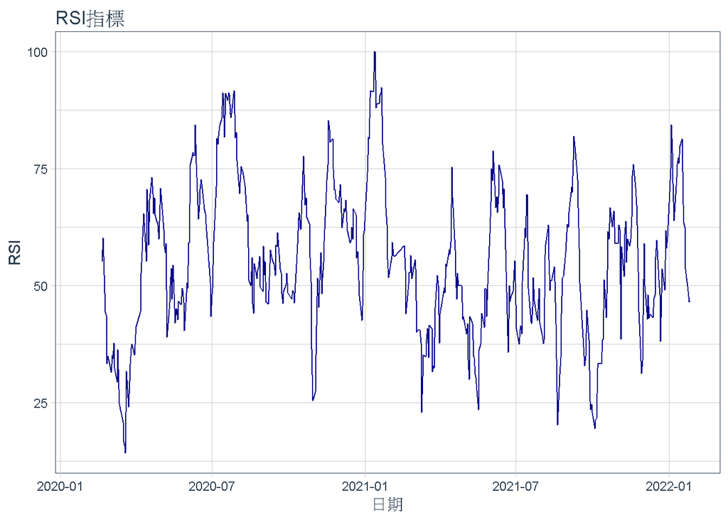

```r
p1 <- ggplot(Result) +
        geom_line(aes(x = 年月日, y = RSI),colour = 'darkblue') +
        labs(title = 'RSI指標', x = '日期', y = 'RSI') +
        theme_tq() +
        scale_color_tq()

print(p1)
```

# Yahoo財經資料繪製股價及RSI圖

```r
library(quantmod)
getSymbols("2330.TW",from = "2020-05-01",to = '2022-05-31',src = "yahoo")
```

```
## [1] "2330.TW"
```

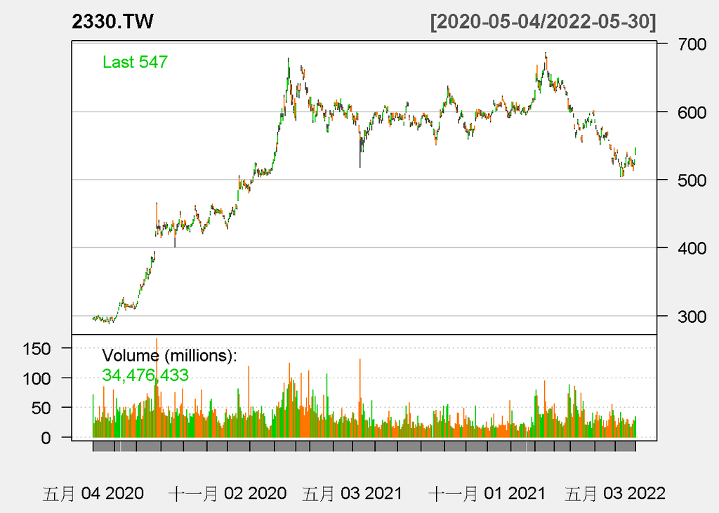

```r
chartSeries(`2330.TW`,subset='2020-05::2022-05',theme = 'white')
```

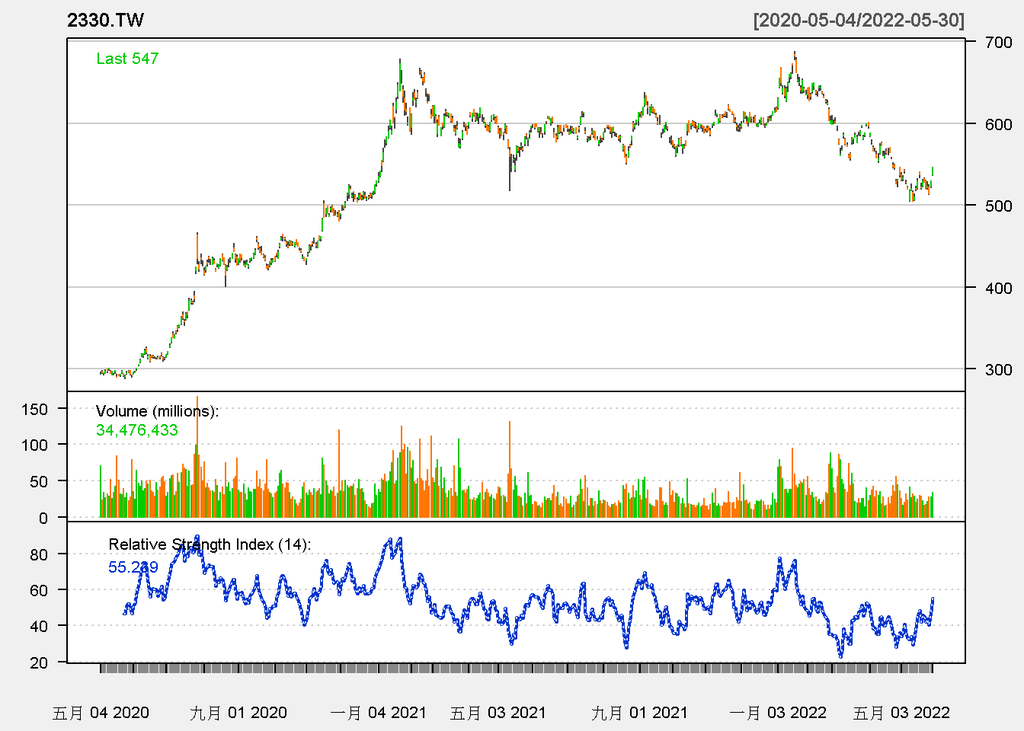

```r
addRSI(14)
```

# 建構最佳化函數

```r
Best <- function(number,beging,end,pos_min,pos_max){
  income <- c()
  t <- c()
  RSILower <- c()
  RSIUpper <- c()
  Posimin <- c()
  Posimax <- c()

  for (a in c(6,14,30,60)) {
    for (b in c(20,30)) {
      for (c in c(70,80)) {
        for (d in c(pos_min:0)) {
          for (e in c(1:pos_max)) {
            df <- RSI_BackTest(number,beging,end,a,b,c,d,e)
            income[(length(income)+1)] <- df$累積損益[nrow(df)]
            t[(length(t)+1)] <- a
            RSILower[(length(RSILower)+1)] <- b
            RSIUpper[(length(RSIUpper)+1)] <- c
            Posimin[(length(Posimin)+1)] <- d
            Posimax[(length(Posimax)+1)] <- e
          }

        }
      }

    }
  }

  df_2 <- data.frame(天數設定 = t,
                     買訊 = RSILower,
                     賣訊 = RSIUpper,
                     部位下限 = Posimin,
                     部位上限 = Posimax,
                     累積損益 = income)

  df_3 <- df_2 %>% arrange(desc(累積損益))
  cat('#####################\n')
  cat('根據歷史資料回測該股票之最佳化參數\n')
  cat('天數設定',df_3[1,1],'\n')
  cat('買訊',df_3[1,2],'\n')
  cat('賣訊',df_3[1,3],'\n')
  cat('部位下限',df_3[1,4],'\n')
  cat('部位上限',df_3[1,5],'\n')
  cat('累積損益',df_3[1,6],'\n')
  cat('#####################\n')
}
```

# 參數最佳化

選定一檔股票，設定日期區間及可承受之部位上下限，可根據歷史資料對找出執行RSI指標交易策略之最佳參數組合。  
本範例設定  
持有部位下限:-5  
持有部位上限:5

```r
Best('2330','2020-01-31','2022-01-31',-5,5)
```

```
## #####################
## 根據歷史資料回測該股票之最佳化參數
## 天數設定 6
## 買訊 30
## 賣訊 80
## 部位下限 0
## 部位上限 5
## 累積損益 1637
## #####################
```